# R Notebook

# Embora o Auto ARIMA tenha encontrado um modelo com AIC muito menor, em um curso introdutório é muito mais importante que os alunos compreendam toda a lógica da metodologia Box-Jenkins utilizando um modelo simples e facilmente interpretável.

#Diagnóstico do ARIMA(1,1,0)

```r
summary(m1)
```

```
Series: treino
ARIMA(1,1,0)

Coefficients:
         ar1
      0.5194
s.e.  0.0628

sigma^2 = 0.1665:  log likelihood = -95.28
AIC=194.55   AICc=194.62   BIC=200.97

Training set error measures:
                      ME      RMSE       MAE        MPE     MAPE      MASE        ACF1
Training set 0.002431576 0.4058035 0.2870474 0.05163991 5.553138 0.1260426 -0.00590985
```

#Gráfico Completo. Gráfico dos resíduos Desejamos: média próxima de zero;ausência de tendência; ausência de padrão. Histograma Desejamos:formato aproximadamente normal. ACF dos resíduos Desejamos: todas as barras dentro dos limites. Isso indica: Ausência de autocorrelação residual.

```
    Ljung-Box test

data:  Residuals from ARIMA(1,1,0)
Q* = 62.722, df = 23, p-value = 1.529e-05

Model df: 1.   Total lags used: 24
```

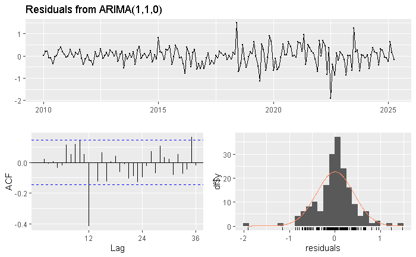

```r
checkresiduals(m1)
```

## Os residuos devem ser ruido branco

# Teste de Ljung-Box. Hipóteses H0: Os resíduos são ruído branco. H1: Os resíduos possuem autocorrelação. Interpretação Se: p > 0.05 Conclusão: O modelo é adequado.

```r
Box.test(
  residuals(m1),
  lag=24,
  type="Ljung"
)
```

```
    Box-Ljung test

data:  residuals(m1)
X-squared = 62.722, df = 24, p-value = 2.611e-05
```

# Previsão Fora da Amostra. Agora vamos avaliar a capacidade preditiva.

# Gerando Previsões

```r
prev_m1 <- forecast(
  m1,
  h=12
)
```

# Visualizando

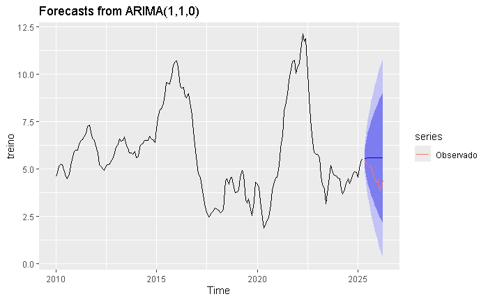

```r
autoplot(prev_m1)+
  autolayer(
    teste,
    series="Observado"
  )
```

### O gráfico mostra o intervalo da série

# Comparação Numérica

```r
comparacao <- data.frame(
  Real = as.numeric(teste),
  Previsto = as.numeric(prev_m1$mean)
)

comparacao
```

| Real | Previsto |
| --- | --- |
| 5.32 | 5.555970 |
| 5.35 | 5.569459 |
| 5.23 | 5.576465 |
| 5.13 | 5.580104 |
| 5.17 | 5.581994 |
| 4.68 | 5.582975 |
| 4.46 | 5.583485 |
| 4.26 | 5.583750 |
| 4.44 | 5.583888 |
| 3.81 | 5.583959 |

[output cut: 2 more lines]

#Avaliação da Previsão. Agora vamos medir o erro.

# MAE. Erro Absoluto Médio

```r
mae(
  teste,
  prev_m1$mean
)
```

```
[1] 0.8808383
```

# MSE. Erro Quadrático Médio

```r
mse(
  teste,
  prev_m1$mean
)
```

```
[1] 1.032693
```

# RMSE

```r
rmse(
  teste,
  prev_m1$mean
)
```

```
[1] 1.016215
```

# MAPE. O mais utilizado em Economia. Interpretação MAPE Qualidade. < 10% Excelente, 10% - 20% Boa, 20% - 50% Aceitável e > 50% Ruim

```r
mape(
  teste,
  prev_m1$mean
)*100
```

```
[1] 20.15542
```

# Previsão Final.Agora utilizaremos toda a amostra.

# Reestimando

```r
modelo_final <- Arima(
  serie,
  order=c(1,1,0)
)
```

# Previsão para os Próximos 6 Meses

```r
prev6 <- forecast(
  modelo_final,
  h=6
)

prev6
```

|  | Point Forecast | Lo 80 | Hi 80 | Lo 95 | Hi 95 |
| --- | --- | --- | --- | --- | --- |
| May 2026 | 4.516113 | 3.997996 | 5.034229 | 3.723722 | 5.308503 |
| Jun 2026 | 4.579730 | 3.643763 | 5.515697 | 3.148292 | 6.011169 |
| Jul 2026 | 4.611822 | 3.305473 | 5.918172 | 2.613933 | 6.609712 |
| Aug 2026 | 4.628011 | 2.996229 | 6.259793 | 2.132416 | 7.123606 |
| Sep 2026 | 4.636177 | 2.716382 | 6.555973 | 1.700104 | 7.572251 |
| Oct 2026 | 4.640297 | 2.462446 | 6.818148 | 1.309561 | 7.971033 |

# Gráfico

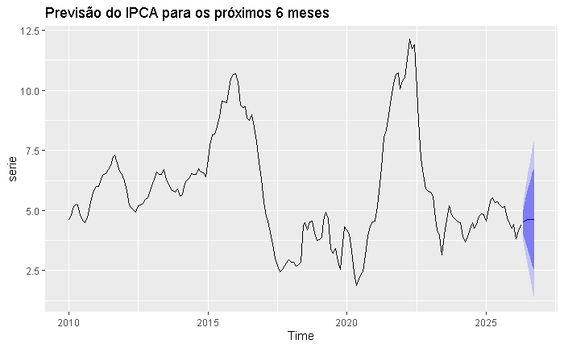

```r
autoplot(prev6)+
  ggtitle(
    "Previsão do IPCA para os próximos 6 meses"
  )
```

# agora vamos trabalhar com modelo do auto arima

#Resumo do Modelo

```r
summary(m6)
```

```
Series: treino
ARIMA(2,0,2)(0,0,1)[12] with non-zero mean

Coefficients:
         ar1      ar2      ma1      ma2     sma1    mean
      1.9275  -0.9346  -0.5249  -0.2583  -0.8818  5.8674
s.e.  0.0493   0.0479   0.0938   0.0838   0.0805  0.1506

sigma^2 = 0.09463:  log likelihood = -52.03
AIC=118.06   AICc=118.69   BIC=140.56

Training set error measures:
                      ME      RMSE       MAE        MPE     MAPE       MASE       ACF1
Training set 0.006510216 0.3025615 0.2231939 -0.2953765 4.394314 0.09800453 0.02681321
```

#Diagnóstico Gráfico

```
    Ljung-Box test

data:  Residuals from ARIMA(2,0,2)(0,0,1)[12] with non-zero mean
Q* = 24.907, df = 19, p-value = 0.1636

Model df: 5.   Total lags used: 24
```

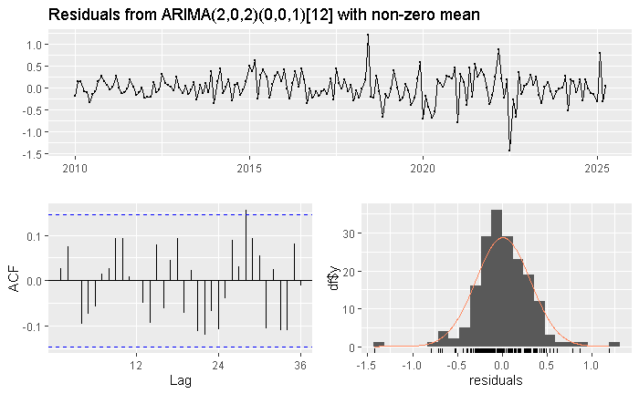

```r
checkresiduals(m6)
```

#Teste de Ljung-Box

```r
Box.test(
  residuals(m6),
  lag = 24,
  type = "Ljung"
)
```

```
    Box-Ljung test

data:  residuals(m6)
X-squared = 24.907, df = 24, p-value = 0.4108
```

# Previsão Fora da Amostra. Agora vamos utilizar os 12 meses reservados para teste.

#Gerar Previsões

```r
prev_auto <- forecast(
  m6,
  h = 12
)
```

# Visualizar

```r
prev_auto
```

|  | Point Forecast | Lo 80 | Hi 80 | Lo 95 | Hi 95 |
| --- | --- | --- | --- | --- | --- |
| May 2025 | 5.482149 | 5.087123 | 5.877175 | 4.878009 | 6.086289 |
| Jun 2025 | 5.631374 | 4.950916 | 6.311832 | 4.590703 | 6.672044 |
| Jul 2025 | 5.597945 | 4.692938 | 6.502952 | 4.213857 | 6.982034 |
| Aug 2025 | 5.874906 | 4.770938 | 6.978874 | 4.186533 | 7.563280 |
| Sep 2025 | 5.884753 | 4.598062 | 7.171444 | 3.916928 | 7.852578 |
| Oct 2025 | 5.937121 | 4.480376 | 7.393866 | 3.709221 | 8.165020 |
| Nov 2025 | 6.124140 | 4.508457 | 7.739822 | 3.653166 | 8.595113 |
| Dec 2025 | 6.364476 | 4.600258 | 8.128694 | 3.666338 | 9.062615 |
| Jan 2026 | 6.770343 | 4.867609 | 8.673077 | 3.860363 | 9.680323 |
| Feb 2026 | 6.274902 | 4.243434 | 8.306369 | 3.168040 | 9.381763 |

[output cut: 2 more lines]

# Gráfico

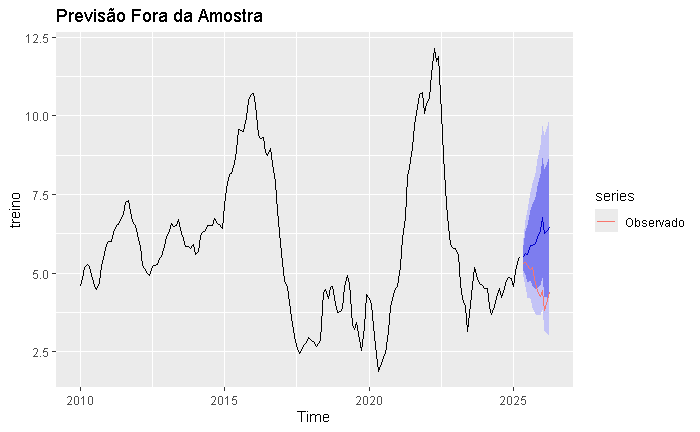

```r
autoplot(prev_auto)+
  autolayer(
    teste,
    series = "Observado"
  )+
  ggtitle(
    "Previsão Fora da Amostra"
  )
```

# Comparação Numérica

```r
comparacao <- data.frame(

Data =
time(teste),

Real =
as.numeric(teste),

Previsto =
as.numeric(prev_auto$mean)

)

comparacao
```

| Data | Real | Previsto |
| --- | --- | --- |
| 2025.333 | 5.32 | 5.482149 |
| 2025.417 | 5.35 | 5.631374 |
| 2025.500 | 5.23 | 5.597945 |
| 2025.583 | 5.13 | 5.874906 |
| 2025.667 | 5.17 | 5.884753 |
| 2025.750 | 4.68 | 5.937121 |
| 2025.833 | 4.46 | 6.124140 |
| 2025.917 | 4.26 | 6.364476 |
| 2026.000 | 4.44 | 6.770343 |
| 2026.083 | 3.81 | 6.274902 |

[output cut: 2 more lines]

# Erro de Previsão

```r
comparacao$Erro <-
comparacao$Real -
comparacao$Previsto

comparacao
```

[output not shown]

# Avaliação da Qualidade da Previsão

#MAE

```r
mae(
  teste,
  prev_auto$mean
)
```

[output not shown]

#MSE

```r
mse(
  teste,
  prev_auto$mean
)
```

[output not shown]

#RMSE

```r
rmse(
  teste,
  prev_auto$mean
)
```

[output not shown]

MAPE

```r
mape(
  teste,
  prev_auto$mean
)*100
```

```
[1] 31.24622
```

#previsão final. Agora utilizamos toda a amostra.

#Reestimar

```r
modelo_final <- auto.arima(
  serie
)

summary(
  modelo_final
)
```

```
Series: serie
ARIMA(2,0,4)(0,0,1)[12] with non-zero mean

Coefficients:
         ar1      ar2      ma1      ma2      ma3      ma4     sma1    mean
      1.9549  -0.9597  -0.5414  -0.1738  -0.0660  -0.1123  -0.8840  5.8104
s.e.  0.0318   0.0304   0.0811   0.0837   0.0839   0.0820   0.0739  0.1144

sigma^2 = 0.09109:  log likelihood = -50.5
AIC=119   AICc=119.96   BIC=148.5

Training set error measures:
                     ME      RMSE       MAE        MPE     MAPE      MASE        ACF1
Training set 0.01071164 0.2955839 0.2182225 -0.1731348 4.295809 0.1000073 0.004450244
```

# Previsão para 6 meses

```r
prev6 <- forecast(
  modelo_final,
  h = 6
)

prev6
```

|  | Point Forecast | Lo 80 | Hi 80 | Lo 95 | Hi 95 |
| --- | --- | --- | --- | --- | --- |
| May 2026 | 4.637480 | 4.250025 | 5.024935 | 4.044919 | 5.230041 |
| Jun 2026 | 4.827772 | 4.156868 | 5.498676 | 3.801713 | 5.853831 |
| Jul 2026 | 4.950344 | 4.028922 | 5.871766 | 3.541150 | 6.359538 |
| Aug 2026 | 5.322576 | 4.175322 | 6.469829 | 3.568003 | 7.077148 |
| Sep 2026 | 5.337610 | 4.000627 | 6.674593 | 3.292871 | 7.382349 |
| Oct 2026 | 5.857225 | 4.354447 | 7.360003 | 3.558924 | 8.155526 |

#Gráfico Final

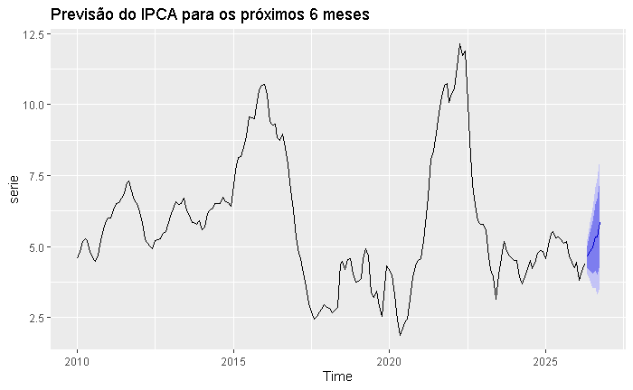

```r
autoplot(prev6)+
  ggtitle(
    "Previsão do IPCA para os próximos 6 meses"
  )
```

# Trabalhando agora com os dados do PIB

# Importar os dados

```r
pib <- read_excel(
  "../dados/pib.xls",
  sheet="Séries"
)

head(pib)
```

| Data | PIB |
| --- | --- |
| 2002 T1 | 342296.6 |
| 2002 T2 | 367362.8 |
| 2002 T3 | 379794.5 |
| 2002 T4 | 399333.2 |
| 2003 T1 | 397241.6 |
| 2003 T2 | 418987.3 |

# Transformar para Numérico

```r
str(pib)
```

```
tibble [97 × 2] (S3: tbl_df/tbl/data.frame)
 $ Data: chr [1:97] "2002 T1" "2002 T2" "2002 T3" "2002 T4" ...
 $ PIB : num [1:97] 342297 367363 379795 399333 397242 ...
```

```r
pib$PIB <- as.numeric(pib$PIB)
```

# Criar a série trimestral

```r
pib_ts <- ts(
  pib$PIB,
  start=c(2002,1),
  frequency=4
)
```

#Visualizar PIB

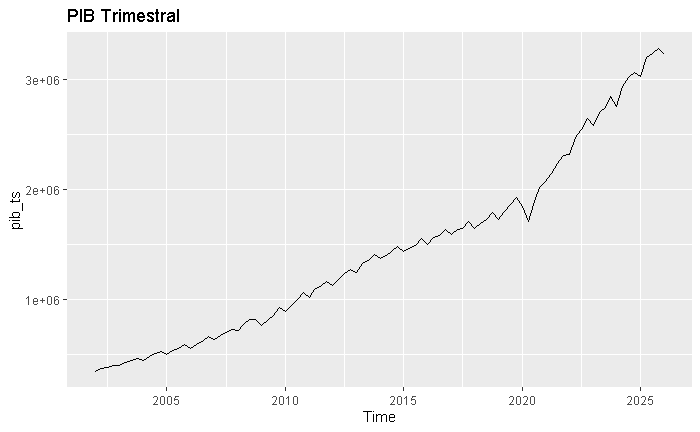

```r
autoplot(pib_ts)+
  ggtitle("PIB Trimestral")
```

# Aplicar logaritmo. Nesta etapa já devemos observar uma redução significativa da variância.O log comprime a escala. Diferenças passam a representar taxas de crescimento.

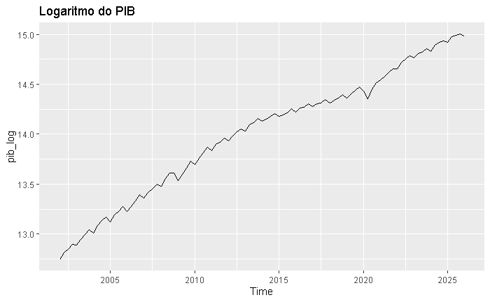

```r
pib_log <- log(pib_ts)

autoplot(pib_log)+
  ggtitle("Logaritmo do PIB")
```

# Estatísticas Descritivas

```r
summary(pib_log)
```

```
   Min. 1st Qu.  Median    Mean 3rd Qu.    Max.
  12.74   13.50   14.15   14.01   14.43   15.00
```

```r
mean(pib_log)
```

```
[1] 14.009
```

```r
sd(pib_log)
```

```
[1] 0.6261428
```

```r
var(pib_log)
```

```
[1] 0.3920548
```

#Decomposição

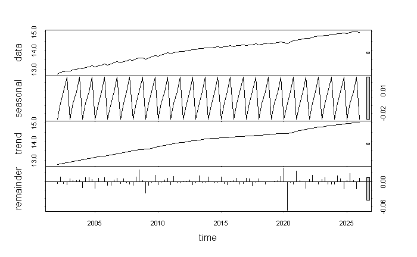

```r
decomp <- stl(
  pib_log,
  s.window="periodic"
)

plot(decomp)
```

####Tendencia de crescimento do PIB #Teste de Tendência

```r
tempo <- 1:length(pib_log)

summary(
  lm(pib_log ~ tempo)
)
```

```
Call:
lm(formula = pib_log ~ tempo)

Residuals:
     Min       1Q   Median       3Q      Max
-0.20855 -0.05591 -0.01477  0.07241  0.16887

Coefficients:
             Estimate Std. Error t value Pr(>|t|)
(Intercept) 1.293e+01  1.800e-02  718.32   <2e-16 ***
tempo       2.203e-02  3.189e-04   69.07   <2e-16 ***
---
Signif. codes:  0 ‘***’ 0.001 ‘**’ 0.01 ‘*’ 0.05 ‘.’ 0.1 ‘ ’ 1

Residual standard error: 0.08795 on 95 degrees of freedom
Multiple R-squared:  0.9805,    Adjusted R-squared:  0.9803
F-statistic:  4770 on 1 and 95 DF,  p-value: < 2.2e-16
```

# Teste de Sazonalidade

```r
tri <- factor(cycle(pib_log))

summary(
  lm(pib_log ~ tri)
)
```

```
Call:
lm(formula = pib_log ~ tri)

Residuals:
    Min      1Q  Median      3Q     Max
-1.2346 -0.5021  0.1507  0.4183  1.0080

Coefficients:
             Estimate Std. Error t value Pr(>|t|)
(Intercept) 13.977980   0.127060 110.011   <2e-16 ***
tri2         0.004659   0.181552   0.026    0.980
tri3         0.040070   0.181552   0.221    0.826
tri4         0.080624   0.181552   0.444    0.658
---
Signif. codes:  0 ‘***’ 0.001 ‘**’ 0.01 ‘*’ 0.05 ‘.’ 0.1 ‘ ’ 1

Residual standard error: 0.6353 on 93 degrees of freedom
Multiple R-squared:  0.002703,  Adjusted R-squared:  -0.02947
F-statistic: 0.08404 on 3 and 93 DF,  p-value: 0.9686
```

# Estacionariedade

# ADF

```r
adf.test(pib_log)
```

```
    Augmented Dickey-Fuller Test

data:  pib_log
Dickey-Fuller = -2.0107, Lag order = 4, p-value = 0.5721
alternative hypothesis: stationary
```

#KPSS

```r
kpss.test(pib_log)
```

```
    KPSS Test for Level Stationarity

data:  pib_log
KPSS Level = 2.4644, Truncation lag parameter = 3, p-value = 0.01
```

#PP

```r
pp.test(pib_log)
```

```
    Phillips-Perron Unit Root Test

data:  pib_log
Dickey-Fuller Z(alpha) = -6.7832, Truncation lag parameter = 3, p-value = 0.7222
alternative hypothesis: stationary
```

#Primeira Diferença:Taxa de crescimento trimestral do PIB.

```r
pib_d1 <- diff(pib_log)
```

#Visualização

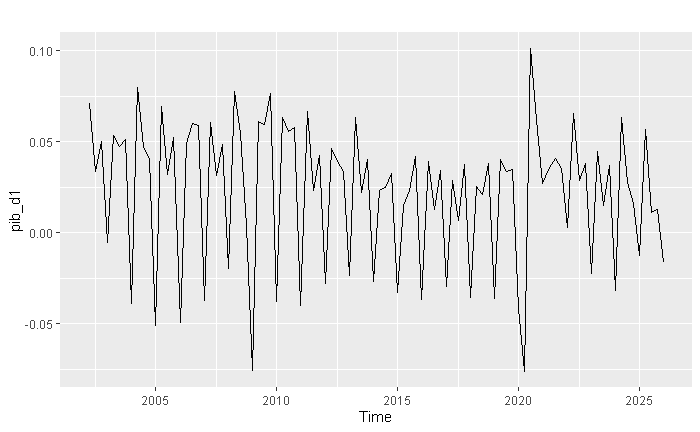

```r
autoplot(pib_d1)
```